# PySpice_EyePoint_CurveTracer

## часть проекта по восстановлению электронной схемы характериографом

## https://github.com/vasily84/PySpice_CurveTracer

### Необходимы - python3.x, sklearn,PySpice

### необходимые библиотеки -

### PySpice - симуляция электронных схем из Python

https://pyspice.fabrice-salvaire.fr/

https://github.com/FabriceSalvaire/PySpice

### scikit-learn библиотека машинного обучения

https://scikit-learn.org/stable/index.html

## Как использовать?

### Необходимо задать рабочую папку программы в переменной FILEBASE_ROOT ( ячейка ниже).

### Варианты запуска программы :

- Первый запуск - Папка задана, но не существует: программа создаст папку и скачает библиотеку spice компонентов из github, затем сгенерирует синтетические данные для схем, описанных в коде и построит модели машинного обучения для них. Для каждой модели создается отдельная папка внутри FILEBASE_ROOT. Туда же пишется её .pickle образ. При последующих запусках модели будут подгружаться с диска.
- Второй и прочие запуски - (папка FILEBASE_ROOT содержит библиотеку spice компонентов и дополнительные папки с обученными моделями) обученные модели загружаются с диска.
- При необходимости переобучить модель - можно удалить файл модели .pickle из ее подпапки или всю её подпапку - при следующем запуске ноутбука модель будет перетренирована.
- При необходимости перенести ноутбук целиком на другой компьютер можно скопировать папку FILEBASE_ROOT и указать правильные пути к ней, но следует помнить о возможной несовместимости .pickle объектов для разных версий питона и библиотек.

### Код написан последовательно сверху вниз-

### для тестирования и исследовательских целей удобнее всего запускать ноутбук целиком Menu->Kernel->Restart & Run All, помещая необходимый дополнительный код в самые нижние ячейки ноутбука, и затем дописывая и запуская ячейки

```python
FILEBASE_ROOT = 'E:\EyePoint' # путь к рабочей папке программы
```

```python
import numpy as np
import matplotlib.pyplot as plt
from tqdm import tqdm
import itertools
from sklearn import __version__ as sk_version
from scipy.signal import resample

import PySpice
import PySpice.Logging.Logging as Logging
from PySpice.Spice.Netlist import Circuit
from PySpice.Spice.Library import SpiceLibrary
from PySpice.Doc.ExampleTools import find_libraries
from PySpice.Unit import *

import os
import uuid
import random
import requests
import zipfile

logger = Logging.setup_logging()
PySpice.show_version()

print('sklearn version '+sk_version)

Circuit_Set = set() # set of all availible curcuits
```

```
PySpice Version 1.4.3
sklearn version 1.0.2
```

### проверяем пути к рабочей папке, при необходимости подгружаем spice библиотеки компонентов и обученные модели с github

```python
def download_and_unzip(filePath):
    print('downloading started..')

    url = 'https://github.com/vasily84/PySpice_CurveTracer/raw/main/spice_library.zip'
    # Downloading the file by sending the request to the URL
    req = requests.get(url)

    zipName = os.path.join(filePath,'temp.zip')
    print('from '+str(url)+'\ndownloaded '+str(len(req.content))+' bytes')

    # Writing the file to the local file system
    with open(zipName,'wb') as output_file:
        output_file.write(req.content)
    print('downloading completed, UnZip started..')

    # unzip
    with zipfile.ZipFile(zipName, 'r') as zip_ref:
        zip_ref.extractall(filePath)

    os.remove(zipName)
    print('UnZip completed..')


# проверяем пути к рабочей папке,
# при необходимости подгружаем spice библиотеки компонентов
# и обученные модели с github
if not os.path.exists(FILEBASE_ROOT):
    os.makedirs(FILEBASE_ROOT)
    download_and_unzip(FILEBASE_ROOT)

print('\nsimulation dataset on:\n'+FILEBASE_ROOT)

libraries_path = os.path.join(FILEBASE_ROOT,'spice_library')
print('\nspice models library on:\n'+libraries_path)
spice_library = SpiceLibrary(libraries_path)
print(spice_library['1N4148'])
```

```
simulation dataset on:
E:\EyePoint

spice models library on:
E:\EyePoint\spice_library
E:\EyePoint\spice_library\diode\switching\1N4148.lib
```

### код CreateCVC базируется на библиотеке MySpice

https://github.com/LukyanovM/MySpice

используем эту библиотеку, ибо она максимально близко имитирует прибор EyePoint https://eyepoint.physlab.ru/ru/

```python
import math
import numpy

class CurveTracer_Settings():
    """ EyePoint hardware settings struct"""
    def __init__(self,F=10_000,V=3.3,Rcs=0,SNR=40.0,lendata=100,cycle=3):
        self.F = F
        self.V = V
        self.Rcs = Rcs
        self.SNR = SNR
        self.lendata = lendata
        self.cycle = cycle

    def to_numpy(self):
        arr = np.array([self.F, self.V, self.Rcs, self.SNR, self.lendata, self.cycle])
        return arr

    def from_numpy(self,arr):
        self.F = arr[0]
        self.V = arr[1]
        self.Rcs = arr[2]
        self.SNR = arr[3]
        self.lendata = arr[4]
        self.cycle = arr[5]

ct_default_settings = CurveTracer_Settings()

def plot_analysis_IV(analysis,ax=None):
    """ plot I(V) curve for analysis """
    if ax is None:
        plt.grid()
        plt.plot(analysis.input_dummy, analysis.VCurrent)
        plt.title('I(V)')
        plt.xlabel('Напряжение [В]')
        plt.ylabel('Сила тока [А]')
        return
    ax.grid()
    ax.plot(analysis.input_dummy, analysis.VCurrent)
    ax.set_title('I(V)')
    ax.set_xlabel('Напряжение [В]')
    ax.set_ylabel('Сила тока [А]')


def CreateCVC(circuit,ct=ct_default_settings):
    cycle = ct.cycle
    lendata = ct.lendata
    period = 1 / ct.F
    rms_voltage = ct.V / math.sqrt(2)
    # добавляем испытательный щуп в схему
    circuit.R('cs', 'input', 'input_dummy', ct.Rcs)
    circuit.AcLine('Current', circuit.gnd, 'input_dummy', rms_voltage=rms_voltage, frequency=ct.F)

    simulator = circuit.simulator()
    analysis = simulator.transient(step_time=period / lendata, end_time=period * cycle)
    analysis.input_dummy = analysis.input_dummy[len(analysis.input_dummy)-lendata:len(analysis.input_dummy)]
    analysis.VCurrent = analysis.VCurrent[len(analysis.VCurrent)-lendata:len(analysis.VCurrent)]
# Расчитываем шум независмо для тока и напряжения исходя из среднеквадратичных значений и одинакового SNR
    avg_V_db = 10 * numpy.log10(numpy.mean(numpy.array(analysis.input_dummy, dtype=float) ** 2))
    avg_Vnoise_db = avg_V_db - ct.SNR
    Vnoise = numpy.random.normal(0, numpy.sqrt(10 ** (avg_Vnoise_db / 10)), len(analysis.input_dummy))
    analysis.input_dummy = numpy.array(analysis.input_dummy, dtype=float) + Vnoise
    avg_I_db = 10 * numpy.log10(numpy.mean(numpy.array(analysis.VCurrent, dtype=float) ** 2))
    avg_Inoise_db = avg_I_db - ct.SNR
    Inoise = numpy.random.normal(0, numpy.sqrt(10 ** (avg_Inoise_db / 10)), len(analysis.VCurrent))
    analysis.VCurrent = numpy.array(analysis.VCurrent, dtype=float) + Inoise
    # удаляем испытательный щуп из схемы
    circuit.Rcs.detach()
    circuit.VCurrent.detach()
    return analysis
```

#### пример использования CreateCVC

```
2022-02-10 19:07:28,083 - PySpice.Spice.NgSpice.Shared.NgSpiceShared - Shared.WARNING - spinit was not found
2022-02-10 19:07:28,085 - PySpice.Spice.NgSpice.Shared.NgSpiceShared - Shared.ERROR - Note: can't find init file.
```

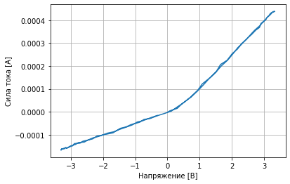

```
Wall time: 558 ms
```

```python
%%time
circuit = Circuit('RD')
circuit.include(spice_library['1N4148'])
circuit.R(1,'input',1,10@u_kOhm)
circuit.X('D1', '1N4148', 1, circuit.gnd)
circuit.R(2,'input',circuit.gnd,20@u_kOhm)

analysis = CreateCVC(circuit)

plt.grid()
plt.plot(analysis.input_dummy, analysis.VCurrent)
plt.xlabel('Напряжение [В]')
plt.ylabel('Сила тока [А]')
plt.show()
```

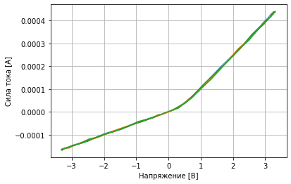

```python
NewPoints = 50
for Points in [120,170,1000]:
    circuit = Circuit('RD')
    circuit.include(spice_library['1N4148'])
    circuit.R(1,'input',1,10@u_kOhm)
    circuit.X('D1', '1N4148', 1, circuit.gnd)
    circuit.R(2,'input',circuit.gnd,20@u_kOhm)

    CurveTracer_Settings(lendata=Points)
    analysis = CreateCVC(circuit)

    plt.grid()
    input_dummy = resample(analysis.input_dummy, NewPoints)
    VCurrent = resample(analysis.VCurrent, NewPoints)
    plt.plot(input_dummy, VCurrent)

plt.xlabel('Напряжение [В]')
plt.ylabel('Сила тока [А]')
plt.show()
```

### как построена база?

каждой схеме соответствует папка, в которой хранятся файлы массивов симуляции c номиналами схемы и параметрами прибора,и circuit файл - информация о самой схеме

```python
%%time
def save_cir_analysis(fileName,circuit_params,curve_params,analysis):
    """ save circuit nominals,curve tracer parameters, voltage and current arrays to file"""
    with open(fileName, 'wb') as f:
        np.save(f,circuit_params)
        np.save(f,curve_params)
        np.save(f,analysis.VCurrent)
        np.save(f,analysis.input_dummy)

def make_sure_path(path_title):
    """ create path if path not exist, return full path """
    dirName = os.path.join(FILEBASE_ROOT,path_title)
    if not os.path.exists(dirName):
        os.makedirs(dirName)
    return dirName

def save_circuit(dirName,circuit):
    """ save sample circuit on disk """
    fileName = os.path.join(dirName,circuit.title+'.cir')
    with open(fileName,'w') as f:
        f.write(str(circuit))
```

```
Wall time: 0 ns
```

```python
def load_circuit_dataset(path_dataset,ct_settings=None,shuffle=True,max_files=None,resample_len=1):
    """ load dataset from circuit folder.
    return X,y """
    fileList = [f for f in os.listdir(path_dataset) if f.endswith('.npy')]

    if shuffle:
        random.shuffle(fileList)

    if max_files is not None:
        max_files = min(max_files,len(fileList))
        fileList=fileList[0:max_files]

    X_data,y_data=[],[]

    for fileName in tqdm(fileList): # process files
        with open(os.path.join(path_dataset,fileName), 'rb') as f:
            circuit_params = np.load(f)
            curve_params = np.load(f)
            VCurrent = np.load(f)
            input_dummy = np.load(f)

            # использование старой базы сигналов для обучения модели.
            # старую базу можно использовать, но модели нужно перестраивать заново
            if resample_len is not None: # ресэмплинг сигнала из базы
                if resample_len==1: # берем текущие настройки прибора по умолчанию
                    resample_len = ct_default_settings.lendata

                if not len(VCurrent)==resample_len:
                    VCurrent = resample(VCurrent,resample_len)
                    input_dummy = resample(input_dummy,resample_len)

            if ct_settings is not None:
                ct = CurveTracer_Settings().from_numpy(curve_params)
                F_ok = math.abs(ct_settings.F-ct.F) < 0.1
                V_ok = math.abs(ct_settings.V-ct.V) < 0.05
                if (F_ok and V_ok)==False:
                    continue

                len_ok = ct_settings.lendata == ct.lendata
                cyc_ok = ct_settings.cycle == ct.cycle
                if (len_ok and cyc_ok)==False:
                    continue

                #Rcs_ok = math.abs(ct_settings.Rcs-ct.Rcs) < 1
                #SNR_ok = True #math.abs(ct_settings.SNR-ct.SNR) < 1

        # append data to arrays
        y_data.append(circuit_params)
        X_data.append([VCurrent,input_dummy])

    return np.array(X_data),np.array(y_data)
```

## препроцессор данных для моделей -

### делает преобразование фурье, прореживание и прочие манипуляции со входными сигналами

#### Мотивация к добавлению в признаковое пространство конкретных алгебраических величин (закон Ома):

Ток $I=V/R$

Сопротивление $R=V/I$

Проводимость $\sigma=1/R=I/V$

Напряжение на конденсаторе $V=C*Q$

Заряд конденсатора $Q=\int Idt \sim \sum {I}$

Емкость конденсатора $C=V/Q$ или $C \sim V/\sum {I}$

Диф. сопротивление $R_d= \frac {\Delta {V}} {\Delta{I}}$

Диф. Проводимость $\sigma_d=1/R_d=\Delta {I}/\Delta {V}$

Напряжение на индуктивности $ V = -L \frac {\Delta{I}} {\Delta{t}} \sim L\Delta{I}$

Величина индуктивности $L \sim \frac {V} {\Delta{I}}$

##### Итого - параметры R, C, L линейно связаны с сигналами V, I, их производными (изменениями от точке к точке) и интегралами (суммами)

#### Мотивация к использованию логарифмов:

$\log {(AB)} = \log {A}+\log {B} $

$\log {\frac {A} {B}} = \log {A}-\log{B}$

##### Итого - можно взять логарифмы от исходных сигналов, их производных и интегралов, и линейная модель их свяжет с логарифмами искомых параметров R, C, L.

```python
from sklearn.preprocessing import FunctionTransformer,StandardScaler
from scipy.fft import rfft

def my_xgb_transform_function(X):
    """ feature engineering on raw analysis signal data.
    Transformations - fft image, input signal resampling etc."""
    Xa = []
    for x in X:
        I_signal = x[:len(x)//2] # current
        V_signal = x[len(x)//2:] # input voltage - not use
        I_fft = rfft(I_signal)
        I_fft = I_fft[:20] # use only first 20 points on freq domain
        I_abs = np.abs(I_fft)
        I_angle = np.angle(I_fft)
        I_real = np.real(I_fft)
        I_imag = np.imag(I_fft)

        V_fft = rfft(V_signal)
        V_fft = V_fft[:20] # use only first 20 points on freq domain
        V_abs = np.abs(V_fft)
        V_angle = np.angle(V_fft)
        V_real = np.real(V_fft)
        V_imag = np.imag(V_fft)

        x1 = np.hstack((x,I_abs,I_angle,I_real,I_imag,V_abs,V_angle,V_real,V_imag))
        Xa.append(x1)

    return np.array(Xa)

def my_rfft_transform_function(X):
    """ feature engineering on raw analysis signal data.
    Transformations - fft image, input signal resampling etc."""
    Xa = []
    for x in X:
        I_signal = x[:len(x)//2] # current
        V_signal = x[len(x)//2:] # input voltage - not use
        I_fft = rfft(I_signal)

        I_abs = np.abs(I_fft)
        I_angle = np.angle(I_fft)
        I_real = np.real(I_fft)
        I_imag = np.imag(I_fft)

        V_fft = rfft(V_signal)

        V_abs = np.abs(V_fft)
        V_angle = np.angle(V_fft)
        V_real = np.real(V_fft)
        V_imag = np.imag(V_fft)

        x1 = np.hstack((I_abs,I_angle,I_real,I_imag,V_abs,V_angle,V_real,V_imag))
        Xa.append(x1)

    return np.array(Xa)

def my_linear_transform_function(X):
    """ feature engineering on raw analysis signal data.
    Transformations - fft image, input signal resampling etc."""
    Xa = []
    for x in X:
        I_signal = x[:len(x)//2] # current
        V_signal = x[len(x)//2:] # input voltage - not use
        Q_signal = np.cumsum(I_signal)
        dI_signal = np.diff(I_signal)
        dV_signal = np.diff(V_signal)

        x1 = np.hstack((I_signal,V_signal,Q_signal,dI_signal,dV_signal))
        Xa.append(x1)

    return np.array(Xa)

MyXGBTransformer = FunctionTransformer(my_xgb_transform_function)
MyRfftTransformer = FunctionTransformer(my_rfft_transform_function)
MyLinearTransformer = FunctionTransformer(my_linear_transform_function)
```

## базовый класс схем

```python
import pickle
from scipy.optimize import minimize
from sklearn.metrics import mean_squared_error
from sklearn.linear_model import LinearRegression, LassoCV,RidgeCV
from sklearn.svm import SVR
from sklearn.ensemble import GradientBoostingRegressor, ExtraTreesRegressor,RandomForestRegressor
from sklearn.multioutput import RegressorChain
from sklearn.pipeline import make_pipeline

class BaseCircuitModel():
    """ base class for circuit models. Provide training, data preprocessing,
    prediction for nominal values """
    def __init__(self,title='baseAbstract',modelDir=None,modelName=None,estimator=None):
        self.title = title
        self.estimator = estimator
        self.modelDir = os.path.join(FILEBASE_ROOT,self.title) if (modelDir is None) else modelDir
        make_sure_path(self.modelDir)
        self.modelName = title+'.pickle' if (modelName is None) else modelName
        self.modelFileName = os.path.join(self.modelDir,self.modelName)
        self.optimize_save_flag = False
        self.lendata = ct_default_settings.lendata

        try:
            self.load_model()
            return
        except OSError as e:
            print(e)

        print('rebuild model ...')
        self.build_model()


    def load_model(self):
        with open(self.modelFileName, "rb") as f:
                self.model = pickle.load(f)
                self.rank = self.model.rank # number of circuit variative nominals
                self.lendata = self.model.lendata

    def save_model(self):
        with open(self.modelFileName, "wb") as f:
                self.model.rank = self.rank
                self.model.lendata = self.lendata
                pickle.dump(self.model, f)

    def write_dataset(self,Xvals,Vtest=(1., 2.5, 3.3, 5.0)):
        """ circuit batch simulation over params Xvals"""
        for v in Vtest:
            for xval in tqdm(Xvals): # walk over nominals in circuit and create I/V curves
                cir_params = np.array(xval)
                circuit = self.build_circuit(cir_params)
                analysis = CreateCVC(circuit,ct=CurveTracer_Settings(V=v))
                fileName = os.path.join(self.modelDir,uuid.uuid4().hex+'.npy')
                save_cir_analysis(fileName,cir_params,ct_default_settings.to_numpy(),analysis)

    def load_dataset(self):
        """ load dataset from disk. Can be overwritten for feature construction"""
        X_data,y_data = load_circuit_dataset(self.modelDir)
        ADim = X_data.shape[0]
        X_data = X_data.reshape(ADim,-1)
        if self.rank==1: # fit shape 1d regression or Nd regression
            y_data = y_data.reshape(-1)
        else:
            y_data = y_data.reshape(ADim,-1)

        return X_data,y_data

    def build_model(self,save_model=True, test_model=True ):
        print('dataset for model '+self.title+' is loading, please wait..')

        if self.estimator is None:
            baseEstimator = GradientBoostingRegressor()

            if self.rank>1:
                self.model = make_pipeline(MyXGBTransformer,RegressorChain(baseEstimator))
            else:
                self.model = make_pipeline(MyXGBTransformer,baseEstimator)
        else:
            self.model = self.estimator

        try:
            X_data,y_data = self.load_dataset()
        except BaseException as e:
            print(e)
            print('rebuild dataset ...')
            self.rebuild_dataset()
            X_data,y_data = self.load_dataset()

        print('model '+self.title+' is training, please wait..')
        self.model.fit(X_data,y_data)
        self.model.rank = self.rank

        if save_model:
            self.save_model()
            self.load_model()

        if test_model:
            print('test_model() routine for '+self.title+' model:')
            self.test_model()

    def test_model(self):
        print('!!WARNING : test_model() routine for '+self.title+' model not implemented')

    def predict_from_model(self,analysis0,start_minimization=False):
        """ predict X values for circuit, best fitted to analysis0 """
        if len(analysis0.VCurrent)!=self.lendata:
            VCurrent = resample(analysis0.VCurrent,self.lendata)
            input_dummy = resample(analysis0.input_dummy,self.lendata)
            X = np.array([VCurrent,input_dummy]).reshape(-1)
        else:
            X = np.array([analysis0.VCurrent,analysis0.input_dummy]).reshape(-1)
        a = self.model.predict([X])[0]
        if start_minimization:
            a,_ = self.optimize_from_X(analysis0,a)

        return a

    def misfit(self,analysis0, Xvals=None,start_minimization=False):
        """ calculate mse for current from circuit from Xval simulation and from analysis"""
        if Xvals is None:
            Xvals = self.predict_from_model(analysis0)

        if start_minimization:
            Xvals,_ = self.optimize_from_X(analysis0,Xvals)

        circuit = self.build_circuit(Xvals)
        analysis1 = CreateCVC(circuit)

        return mean_squared_error(analysis1.VCurrent,analysis0.VCurrent)

    def _optimize_func(self,Xvals):
        circuit = self.build_circuit(Xvals)
        analysis1 = CreateCVC(circuit)

        if self.optimize_save_flag:
            fileName = os.path.join(self.modelDir,'o_'+uuid.uuid4().hex+'.npy')
            save_cir_analysis(fileName,Xvals,ct_default_settings.to_numpy(),analysis1)

        return mean_squared_error(analysis1.VCurrent,self._analysis0.VCurrent)

    def optimize_from_X(self,analysis0,Xvalues = None):
        if Xvalues is None:
            Xvalues = self.predict_from_model(analysis0).reshape(-1)
        self._analysis0 = analysis0 #

        optimize_result = minimize(self._optimize_func,Xvalues)

        return (optimize_result.x, optimize_result)
```

### Реализация конкретных схем из резисторов, емкостей, индуктивностей и диодов

## rank 1, rank 2

```python
######################################################################

class R_circuit(BaseCircuitModel):
    def __init__(self,modelName=None,estimator=None):
        self.rank = 1
        super().__init__('R',modelName=modelName,estimator=estimator)

    def build_circuit(self,Xvals):
        if isinstance(Xvals, float):
            r1 = Xvals
        elif isinstance(Xvals, list):
            r1 = Xvals[0]
        else: # it is numpy array
            r1 = Xvals.item()
        r1 = np.abs(r1)
        circuit = Circuit('R')
        circuit.R(1,'input',circuit.gnd,r1@u_kOhm)
        return circuit

    def rebuild_dataset(self):
        self.write_dataset(np.random.uniform(0.1,100,size=50))
        self.write_dataset(np.random.uniform(0.0,5,size=50))


    def test_model(self):
        print('actual r \t predicted r \t acc dr/r ')

        for r in np.array([0.1, 1, 1.1, 3., 10., 15., 22., 30., 50., 70., 75., 98., 100.]):
            analysis0 = CreateCVC(self.build_circuit(r))
            x = self.predict_from_model(analysis0)
            acc = np.abs((x-r)/r)
            print(str(r),str(x),str(acc),sep='\t')

Circuit_Set.add(R_circuit())

######################################################################

class C_circuit(BaseCircuitModel):
    def __init__(self,modelName=None,estimator=None):
        self.rank = 1
        super().__init__('C',modelName=modelName,estimator=estimator)

    def build_circuit(self,Xvals):
        if isinstance(Xvals, float):
            c1 = Xvals
        elif isinstance(Xvals, list):
            c1 = Xvals[0]
        else: # it is numpy array
            c1 = Xvals.item()
        c1 = np.abs(c1)
        circuit = Circuit('C')
        circuit.C(1,'input',circuit.gnd,c1@u_uF)
        return circuit

    def rebuild_dataset(self):
        self.write_dataset(np.random.uniform(1e-3,100.,size=50))

    def test_model(self):
        print('actual c \t predicted c \t acc dc/c ')

        for c in np.array([0.1, 1, 1.1, 3., 10., 15., 22., 30., 50., 70., 75., 98., 100.]):
            analysis0 = CreateCVC(self.build_circuit(c))
            x = self.predict_from_model(analysis0)
            acc = np.abs((x-c)/c)
            print(str(c),str(x),str(acc),sep='\t')

Circuit_Set.add(C_circuit())

######################################################################

class L_circuit(BaseCircuitModel):
    def __init__(self,modelName=None,estimator=None):
        self.rank = 1
        super().__init__('L',modelName=modelName,estimator=estimator)

    def build_circuit(self,Xvals):
        if isinstance(Xvals, float):
            l1 = Xvals
        elif isinstance(Xvals, list):
            l1 = Xvals[0]
        else: # it is numpy array
            l1 = Xvals.item()
        l1 = np.abs(l1)
        circuit = Circuit('L')
        circuit.L(1,'input',circuit.gnd,l1@u_uH)
        return circuit

    def rebuild_dataset(self):
        self.write_dataset(np.random.uniform(1e-3,500,size=1000))

    def test_model(self):
        print('actual c \t predicted c \t acc dc/c ')

        for l in np.array([0.1, 1, 1.1, 3., 10., 15., 22., 30., 50., 70., 175., 398., 700.]):
            analysis0 = CreateCVC(self.build_circuit(l))
            x = self.predict_from_model(analysis0)
            acc = np.abs((x-l)/l)
            print(str(l),str(x),str(acc),sep='\t')

Circuit_Set.add(L_circuit())
######################################################################

class DR_circuit(BaseCircuitModel):
    def __init__(self,modelName=None,estimator=None):
        self.rank = 1
        super().__init__('DR',modelName=modelName,estimator=estimator)

    def build_circuit(self,Xvals):
        if isinstance(Xvals, float):
            r1 = Xvals
        elif isinstance(Xvals, list):
            r1 = Xvals[0]
        else: # it is numpy array
            r1 = Xvals.item()
        r1 = np.abs(r1)
        circuit = Circuit('DR')
        circuit.include(spice_library['1N4148'])
        circuit.X('D1', '1N4148', 'input', circuit.gnd)
        circuit.R(1,'input',circuit.gnd,r1@u_kOhm)
        return circuit

    def rebuild_dataset(self):
        self.write_dataset(np.random.uniform(0.1,100,size=50))
        self.write_dataset(np.random.uniform(0.0,5,size=50))

    def test_model(self):
        print('actual r \t predicted r \t acc dr/r ')

        for r in np.array([0.1, 1, 1.1, 3., 10., 15., 22., 30., 50., 70., 75., 98., 100.]):
            analysis0 = CreateCVC(self.build_circuit(r))
            x = self.predict_from_model(analysis0)
            acc = np.abs((x-r)/r)
            print(str(r),str(x),str(acc),sep='\t')

Circuit_Set.add(DR_circuit())
######################################################################

class D_R_circuit(BaseCircuitModel):
    def __init__(self,modelName=None,estimator=None):
        self.rank = 1
        super().__init__('D_R',modelName=modelName,estimator=estimator)

    def build_circuit(self,Xvals):
        if isinstance(Xvals, float):
            r1 = Xvals
        elif isinstance(Xvals, list):
            r1 = Xvals[0]
        else: # it is numpy array
            r1 = Xvals.item()
        r1 = np.abs(r1)
        circuit = Circuit('D_R')
        circuit.include(spice_library['1N4148'])
        circuit.X('D1', '1N4148', 'input', 2)
        circuit.R(1,2,circuit.gnd,r1@u_kOhm)
        return circuit

    def rebuild_dataset(self):
        self.write_dataset(np.random.uniform(0.1,100,size=50))
        self.write_dataset(np.random.uniform(0.0,5,size=50))

    def test_model(self):
        print('actual r \t predicted r \t acc dr/r ')

        for r in np.array([0.1, 1, 1.1, 3., 10., 15., 22., 30., 50., 70., 75., 98., 100.]):
            analysis0 = CreateCVC(self.build_circuit(r))
            x = self.predict_from_model(analysis0)
            acc = np.abs((x-r)/r)
            print(str(r),str(x),str(acc),sep='\t')

Circuit_Set.add(D_R_circuit())
###################################################################

class RC_circuit(BaseCircuitModel):
    def __init__(self,modelName=None,estimator=None):
        self.rank = 2
        super().__init__('RC',modelName=modelName,estimator=estimator)

    def build_circuit(self,Xvals):
        Xvals = np.abs(Xvals)
        r1,c1 = Xvals[0],Xvals[1]

        circuit = Circuit('RC')
        circuit.R(1,'input',circuit.gnd,r1@u_kOhm)
        circuit.C(1,'input',circuit.gnd,c1@u_uF)
        return circuit

    def rebuild_dataset(self):
        X = np.random.uniform(low=[0.1,1e-3],high=[100.,100.],size=(1000,2))
        self.write_dataset(X)

    def test_model(self):
        print('real r','real c','r?','c?','real rc','rc?',sep='\t')

        R = [0.1, 2. , 5. , 10. , 70.]
        C = [1., 0.1, 10., 30., 5.]
        for r,c in zip(R,C):
            analysis0 = CreateCVC(self.build_circuit([r,c]))
            rx,cx = self.predict_from_model(analysis0)
            rc = r*c
            rcx = rx*cx
            print(str(r),str(c),str(rx),str(cx),str(rc),str(rcx),sep='\t')

Circuit_Set.add(RC_circuit())
###################################################################

class R_C_circuit(BaseCircuitModel):
    def __init__(self,modelName=None,estimator=None):
        self.rank = 2
        super().__init__('R_C',modelName=modelName,estimator=estimator)

    def build_circuit(self,Xvals):
        Xvals = np.abs(Xvals)
        r1,c1 = Xvals[0],Xvals[1]

        circuit = Circuit('R_C')
        circuit.R(1,'input',2,r1@u_kOhm)
        circuit.C(1,2, circuit.gnd,c1@u_uF)
        return circuit

    def rebuild_dataset(self):
        X = np.random.uniform(low=[0.1,1e-3],high=[100.,100.],size=(1000,2))
        self.write_dataset(X)

    def test_model(self):
        print('real r','real c','r?','c?','real rc','rc?',sep='\t')

        R = [0.1, 2. , 5. , 10. , 70.]
        C = [1., 0.1, 10., 30., 5.]
        for r,c in zip(R,C):
            analysis0 = CreateCVC(self.build_circuit([r,c]))
            rx,cx = self.predict_from_model(analysis0)
            rc = r*c
            rcx = rx*cx
            print(str(r),str(c),str(rx),str(cx),str(rc),str(rcx),sep='\t')

Circuit_Set.add(R_C_circuit())
###################################################################

class DR_R_circuit(BaseCircuitModel):
    def __init__(self,modelName=None,estimator=None):
        self.rank = 2
        super().__init__('DR_R',modelName=modelName,estimator=estimator)

    def build_circuit(self,Xvals):
        Xvals = np.abs(Xvals)
        r1,r2 = Xvals[0],Xvals[1]

        circuit = Circuit('DR_R')
        circuit.include(spice_library['1N4148'])
        circuit.X('D1', '1N4148', 'input', 2)
        circuit.R(1,'input',2,r1@u_kOhm)
        circuit.R(2,2,circuit.gnd,r2@u_kOhm)

        return circuit


    def rebuild_dataset(self):
        X = np.random.uniform(low=[0.1,0.1],high=[100.,100.],size=(1000,2))
        self.write_dataset(X)

    def test_model(self):
        print('real r1','real r2','r1?','r2?',sep='\t')

        R1 = [0.1, 2. , 5. , 10. , 70.]
        R2 = [1., 0.1, 10., 30., 5.]
        for r1,r2 in zip(R1,R2):
            analysis0 = CreateCVC(self.build_circuit([r1,r2]))
            r1x,r2x = self.predict_from_model(analysis0)
            print(str(r1),str(r2),str(r1x),str(r2x),sep='\t')

Circuit_Set.add(DR_R_circuit())

###################################################################

class DR_DR_circuit(BaseCircuitModel):
    def __init__(self,modelName=None,estimator=None):
        self.rank = 2
        super().__init__('DR_DR',modelName=modelName,estimator=estimator)

    def build_circuit(self,Xvals):
        Xvals = np.abs(Xvals)
        r1,r2 = Xvals[0],Xvals[1]

        circuit = Circuit('DR_DR')
        circuit.include(spice_library['1N4148'])
        circuit.X('D1', '1N4148', 'input', 2)
        circuit.R(1,2,circuit.gnd,r1@u_kOhm)
        circuit.X('D2', '1N4148', 3, 'input')
        circuit.R(2,3,circuit.gnd,r2@u_kOhm)

        return circuit


    def rebuild_dataset(self):
        X = np.random.uniform(low=[0.1,0.1],high=[100.,100.],size=(1000,2))
        self.write_dataset(X)


    def test_model(self):
        print('r1','r2','r1?','r2?',sep='\t')

        R1 = [0.1, 2. , 5. , 10. , 70.]
        R2 = [1., 0.1, 10., 30., 5.]
        for r1,r2 in zip(R1,R2):
            analysis0 = CreateCVC(self.build_circuit([r1,r2]))
            r1x,r2x = self.predict_from_model(analysis0)
            print(str(r1),str(r2),str(r1x),str(r2x),sep='\t')

Circuit_Set.add(DR_DR_circuit())
```

```python
# тестирование разных вариантов моделей
myRegr = make_pipeline(MyLinearTransformer,GradientBoostingRegressor())
Circuit_Set.add(R_circuit('R_1.pickle',myRegr))

myRegr = make_pipeline(MyRfftTransformer,GradientBoostingRegressor())
Circuit_Set.add(R_circuit('R_2.pickle',myRegr))

myRegr = make_pipeline(MyLinearTransformer,RegressorChain(GradientBoostingRegressor()))
Circuit_Set.add(RC_circuit('RC_1.pickle',myRegr))

myRegr = make_pipeline(MyRfftTransformer,RegressorChain(GradientBoostingRegressor()))
Circuit_Set.add(RC_circuit('RC_2.pickle',myRegr))
```

### Реализация конкретных схем из резисторов, емкостей, индуктивностей и диодов

## rank 3

```python
###################################################################

class DR_DR_R_circuit(BaseCircuitModel):
    def __init__(self,modelName=None,estimator=None):
        self.rank = 3
        super().__init__('DR_DR_R',modelName=modelName,estimator=estimator)

    def build_circuit(self,Xvals):
        Xvals = np.abs(Xvals)
        r1,r2,r3 = Xvals[0],Xvals[1],Xvals[2]

        circuit = Circuit('DR_DR_R')
        circuit.include(spice_library['1N4148'])
        circuit.X('D1', '1N4148', 'input', 2)
        circuit.R(1,2,circuit.gnd,r1@u_kOhm)
        circuit.X('D2', '1N4148', 3, 'input')
        circuit.R(2,3,circuit.gnd,r2@u_kOhm)
        circuit.R(3,'input',circuit.gnd,r3@u_kOhm)

        return circuit


    def rebuild_dataset(self):
        X = np.random.uniform(low=[0.1,0.1,0.1],high=[100.,100.,100.],size=(1000,3))
        self.write_dataset(X)


    def test_model(self):
        print('r1','r2','r3','r1?','r2?','r3?',sep='\t')

        R1 = [0.1, 2. , 5. , 10. , 70.]
        R2 = [1., 0.1, 10., 30., 5.]
        R3 = [1., 0.1, 10., 30., 5.]
        for r1,r2,r3 in zip(R1,R2,R3):
            analysis0 = CreateCVC(self.build_circuit([r1,r2,r3]))
            r1x,r2x,r3x = self.predict_from_model(analysis0)
            print(str(r1),str(r2),str(r3),str(r1x),str(r2x),str(r3x),sep='\t')

Circuit_Set.add(DR_DR_R_circuit())
```

### тестирование разных схем

```python
#EP = C_circuit()
#EP.test_model()
```

### Класс для предсказания схемы по ВАХ

```python
class CircuitPredictor():
    """ class for circuit prediction from i,v curves using list of various circuit models"""
    def __init__(self):
        # append all availible circuit models to this list
        self.circuitModels = []
        for cir in Circuit_Set:
            self.circuitModels.append(cir)


    def predict_from_model(self,analysis0):
        """"""
        m_List = []
        for m in self.circuitModels:
            Xvars = m.predict_from_model(analysis0)
            err = m.misfit(analysis0,Xvars)
            m_List.append((Xvars,m,err))

        m_List = sorted(m_List, key = lambda k:k[2])
        best = m_List[0] # best suited model
        return best

    def test_me(self):
        """"""
        self.test_rankN(1)
        self.test_rankN(2)
        self.test_rankN(3)

    def test_rankN(self,N,runsCount = 50,plot_Ok=10,plot_Fail=20):
        print('RANK'+str(N)+' CIRCUIT TESTING ..')
        CIR_N = []
        for cir in Circuit_Set:
            cN = cir
            if cN.rank==N:
                CIR_N.append(cN)

        count_ok = 0
        count_fail = 0

        for _ in range(runsCount):
            objCir = random.choice(CIR_N)

            x = 100*np.random.random(N)

            analysis0 = CreateCVC(objCir.build_circuit(x))
            Xvars, objX,_ = self.predict_from_model(analysis0)
            if isinstance(objX,type(objCir)):
                print('success: '+str(x)+' -> '+str(Xvars)+' circuit '+objX.title)
                count_ok += 1
                if plot_Ok>0:
                    plot_Ok -=1
                    analysis1 = CreateCVC(objX.build_circuit(Xvars))
                    #Xvars_2 = objX.predict_from_model(analysis0,start_minimization=True)
                    #analysis2 = CreateCVC(objX.build_circuit(Xvars_2))
                    print('SUCCESS:')
                    plot_analysis_IV(analysis0)
                    plot_analysis_IV(analysis1)
                    #plot_analysis_IV(analysis2)
                    plt.show()
            else:
                print('!!fail:  '+str(x)+' -> '+str(Xvars)+' '+objCir.title+' detected like '+objX.title)
                count_fail += 1
                if plot_Fail>0:
                    plot_Fail -=1
                    analysis1 = CreateCVC(objX.build_circuit(Xvars))
                    #Xvars_2 = objX.predict_from_model(analysis0,start_minimization=True)
                    #analysis2 = CreateCVC(objX.build_circuit(Xvars_2))
                    print('FAIL:')
                    plot_analysis_IV(analysis0)
                    plot_analysis_IV(analysis1)
                    #plot_analysis_IV(analysis2)
                    plt.show()

        print('\nSUCCESS: '+str(count_ok)+', FAIL: '+str(count_fail)+' of '+str(count_ok+count_fail)+' tests')
```

### тестирование класса предсказания схем

```
RANK1 CIRCUIT TESTING ..
success: [38.4949174] -> 40.32515974383973 circuit D_R
SUCCESS:
```

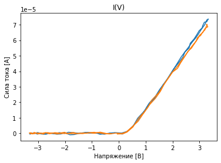

```
success: [72.22829898] -> 71.33090981339784 circuit R
SUCCESS:
```

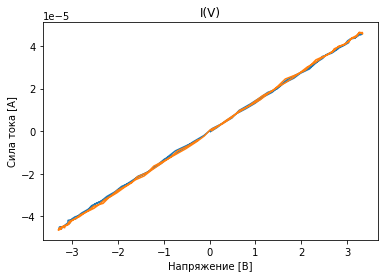

```
success: [28.96005992] -> 25.92091889323801 circuit R
SUCCESS:
```

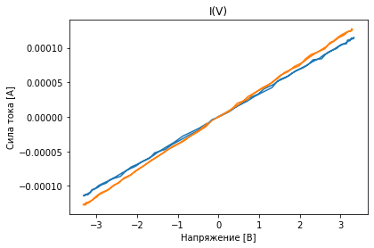

```
!!fail:  [99.68263553] -> [58.80187369 69.08907866] C detected like RC
FAIL:
```

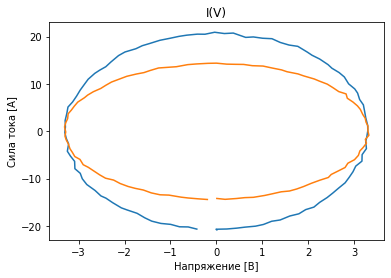

```
success: [86.23682599] -> 87.24406502482736 circuit R
SUCCESS:
```

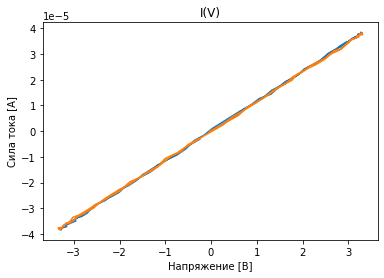

```
success: [61.68625122] -> 66.03270964850387 circuit D_R
SUCCESS:
```

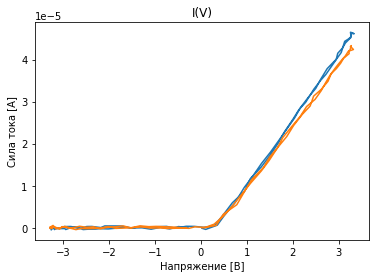

```
success: [73.77337717] -> 81.22106388330008 circuit L
SUCCESS:
```

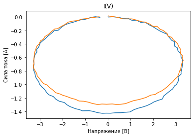

```
!!fail:  [58.1846451] -> [ 6.65326954 52.4165809 ] R detected like DR_R
FAIL:
```

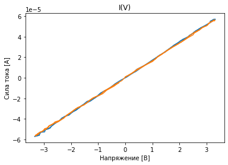

```
!!fail:  [98.60712644] -> [88.69166996 91.41278919] R detected like DR_DR
FAIL:
```

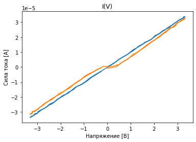

```
!!fail:  [9.57089752] -> [12.38515959 50.57938694] R detected like R_C
FAIL:
```

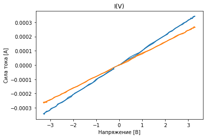

```
success: [49.55056958] -> 50.79263026061443 circuit R
SUCCESS:
```

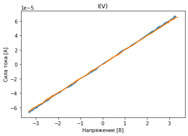

```
!!fail:  [37.9408167] -> [40.62853919 57.70867188] R detected like R_C
FAIL:
```

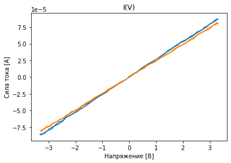

```
success: [11.58548344] -> 11.521192738806146 circuit R
SUCCESS:
```

[65 more figures not shown]

```
!!fail:  [46.90215422  8.2401808  78.84350148] -> [26.80454511  7.37771204] DR_DR_R detected like DR_DR
success: [40.8892239  42.3065589  80.72009592] -> [51.52446983 54.34476529 65.8180604 ] circuit DR_DR_R
success: [84.25109022 82.92419314 19.15125738] -> [77.23204491 80.5134577  20.10203812] circuit DR_DR_R
!!fail:  [14.5531748  20.19271608 22.20985706] -> 10.952881868213039 DR_DR_R detected like R
success: [82.63928879 13.86396954 58.22651899] -> [77.8358791 13.4785326 63.1504295] circuit DR_DR_R
success: [50.48628166  9.62380136 81.06546129] -> [71.04087646  7.7572611  78.8876126 ] circuit DR_DR_R
!!fail:  [ 3.34204522 89.82467058 49.57840683] -> [34.46220438  3.70108232] DR_DR_R detected like DR_R
!!fail:  [ 7.07335947 90.82693738 26.73075412] -> [28.09156105  6.71133003] DR_DR_R detected like DR_R
success: [65.80750619 98.20713904 88.65380105] -> [60.77600824 89.78712708 78.21815428] circuit DR_DR_R
success: [35.54830323 85.20276158 16.0489873 ] -> [37.79498444 78.18869447 18.11404299] circuit DR_DR_R
!!fail:  [63.75118878 58.89873604 25.79499346] -> 19.372846063505097 DR_DR_R detected like R
!!fail:  [17.45575534 32.58489755 16.58098145] -> 11.070569864208213 DR_DR_R detected like R

SUCCESS: 24, FAIL: 26 of 50 tests
```

```python
cre = CircuitPredictor()
cre.test_me()
```